# Bayes Factor Slowdown using ONS data

# Introduction

This document will calculate Bayes Factors based on UK nation datas from the ONS.

```r
pacman::p_load(tidyverse, here, changepoint, segmented, ggrepel, knitr, kableExtra)
```

```r
source(here("scripts", "load_packages_and_functions.R"))
```

```r
write_to_table <- function(x, loc){
  write_csv(x, loc)
  x
}
```

# Load data

```r
dta_e0 <- read_csv(here("data", "e0_from_ons_allnations.csv"))
dta_e0
```

| population | year | sex | e0 |
| --- | --- | --- | --- |
| England | 1980 | female | 76.81 |
| England | 1980 | male | 70.80 |
| England | 1981 | female | 77.11 |
| England | 1981 | male | 71.13 |
| England | 1982 | female | 77.20 |
| England | 1982 | male | 71.29 |
| England | 1983 | female | 77.45 |
| England | 1983 | male | 71.54 |
| England | 1984 | female | 77.79 |
| England | 1984 | male | 71.95 |

[output cut: 536 more lines]

Visualise the life expectancy and change in life expectancy for each year

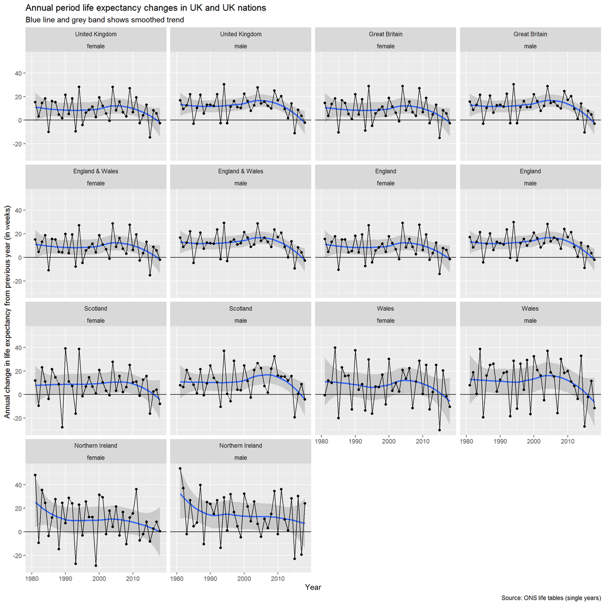

```r
dta_e0 %>%
  group_by(population, sex) %>%
  arrange(year) %>%
  mutate(ch_e0 = e0 - lag(e0)) %>%
  ungroup() %>%
  mutate(
    population = fct_relevel(population, c("United Kingdom", "Great Britain", "England & Wales", "England", "Scotland", "Wales", "Northern Ireland"))
  ) %>%
  mutate(ch_e0 = 52.25 * ch_e0) %>%
  ggplot(aes(x = year, y = ch_e0)) +
  stat_smooth() +
  geom_point() + geom_line() +
  facet_wrap(population ~ sex) +
  geom_hline(yintercept = 0) +
  labs(
    x = "Year", y = "Annual change in life expectancy from previous year (in weeks)",
    title = "Annual period life expectancy changes in UK and UK nations",
    subtitle = "Blue line and grey band shows smoothed trend",
    caption = "Source: ONS life tables (single years)"
  )
```

```r
ggsave(here("figures", "annual_e0_ch_alluknations_ons.png"), height = 25, width = 25, units = "cm", dpi = 300)
```

From the above it seems most populations have seen a slowdown in improvement in recent years, and on average relatively stable improvements previously, with the exception of Northern Ireland, which saw a slowdown in improvement in the 1980s. The smaller populations tend to exhibit greater variability in annual rates of change than the larger populations. The extent of oscillation (negative autocorrelation from one year to the next) also apepars greater in smaller populations. It is not immediately clear that the breakpoint for the slowdown is the same for all UK populations.

Let’s now explore the slowdown by running breakpoint analysis

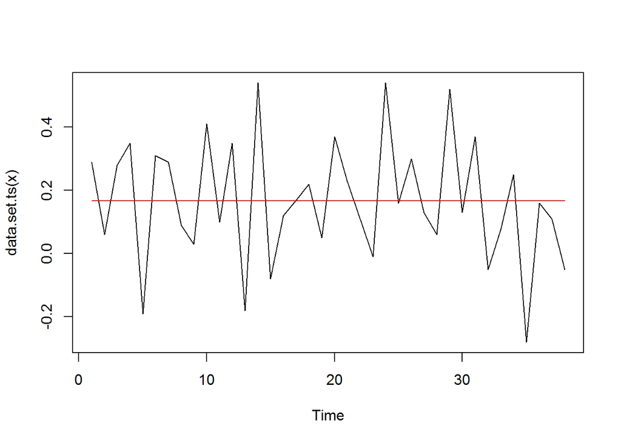

```r
dta_e0 %>%
  group_by(population, sex) %>%
  arrange(year) %>%
  mutate(ch_e0 = e0 - lag(e0)) %>%
  ungroup() %>%
  filter(!is.na(ch_e0)) %>%
  select(-e0) %>%
  mutate(pop_sex = paste(population, sex, sep = "_")) %>%
  select(pop_sex, year, ch_e0) %>%
  filter(pop_sex == "United Kingdom_female") %>%
  pull(ch_e0) %>%
  cpt.mean() %>% plot()
```

```r
# %>%
#   spread(pop_sex, ch_e0) %>% (function(x){
#     tmp <- x %>% pull(year)
#     mtrx <- as.matrix(x %>% select(-year))
#     row.names(mtrx) <- tmp
#     mtrx %>% t()
#   }) %>%
#   cpt.mean(penalty = "None", Q = 2) -> cpts
```

How about package `segmented` instead? This might be more appropriate as the change is apparently gradual rather than discrete

```r
datablocks <-
  dta_e0 %>%
    group_by(population, sex) %>%
    arrange(year) %>%
    mutate(ch_e0 = e0 - lag(e0)) %>%
    ungroup() %>%
    filter(!is.na(ch_e0)) %>%
    select(-e0) %>%
    group_by(population, sex) %>%
    nest()



segmods_1brk <- vector(mode = "list", length = 14)
segmods_2brk <- vector(mode = "list", length = 14)
segmods_3brk <- vector(mode = "list", length = 14)

for (i in 1:14){
  this_data <- datablocks[["data"]][[i]]

  this_linmod <- lm(ch_e0 ~ year, data = this_data)

  this_segmod_1brk <- tryCatch(segmented(this_linmod, npsi = 1, control = seg.control(seed = 1)), finally = NULL)
  this_segmod_2brk <- tryCatch(segmented(this_linmod, npsi = 2, control = seg.control(seed = 1)), finally = NULL)
  this_segmod_3brk <- tryCatch(segmented(this_linmod, npsi = 3, control = seg.control(seed = 1)), finally = NULL)

  segmods_1brk[[i]] <- this_segmod_1brk
  segmods_2brk[[i]] <- this_segmod_2brk
  segmods_3brk[[i]] <- this_segmod_3brk

}
```

[output not shown]

```r
# segmented::segmented()
```

let’s do the above but with five different seeds for a single breakpoint model

```r
segmods1brk_seed01 <- vector(mode = "list", length = 14)
segmods1brk_seed02 <- vector(mode = "list", length = 14)
segmods1brk_seed03 <- vector(mode = "list", length = 14)
segmods1brk_seed06 <- vector(mode = "list", length = 14)
segmods1brk_seed08 <- vector(mode = "list", length = 14)


for (i in 1:14){
  this_data <- datablocks[["data"]][[i]]

  this_linmod <- lm(ch_e0 ~ year, data = this_data)

  segmods1brk_seed01[[i]] <- tryCatch(segmented(this_linmod, npsi = 1, control = seg.control(seed = 1)), finally = NULL)
  segmods1brk_seed02[[i]] <- tryCatch(segmented(this_linmod, npsi = 1, control = seg.control(seed = 2)), finally = NULL)
  segmods1brk_seed03[[i]] <- tryCatch(segmented(this_linmod, npsi = 1, control = seg.control(seed = 3)), finally = NULL)
  segmods1brk_seed06[[i]] <- tryCatch(segmented(this_linmod, npsi = 1, control = seg.control(seed = 6)), finally = NULL)
  segmods1brk_seed08[[i]] <- tryCatch(segmented(this_linmod, npsi = 1, control = seg.control(seed = 8)), finally = NULL)


}
```

Let’s pull the 1 breakpoint estimates

```r
get_brks <- function(x){
  tryCatch(summary(x)$psi[,2], finally = NULL)
}

datablocks %>%
  ungroup() %>%
  mutate(
    segmod_1brk  = segmods_1brk,
    segmod_2brk = segmods_2brk,
    segmod_3brk = segmods_3brk
  ) %>%
  mutate(
    brks_1 = map_dbl(segmod_1brk, get_brks),
    brks_2 = map(segmod_2brk, get_brks),
    brks_3 = map(segmod_3brk, get_brks)
  )
```

| population | sex | data | segmod_1brk | segmod_2brk | segmod_3brk | brks_1 | brks_2 | brks_3 |
| --- | --- | --- | --- | --- | --- | --- | --- | --- |
| England | female |  |  |  |  | 2009.000 |  |  |
| England | male |  |  |  |  | 2009.928 |  |  |
| Northern Ireland | female |  |  |  |  | 1985.000 |  |  |
| Northern Ireland | male |  |  |  |  | 1983.000 |  |  |
| Scotland | female |  |  |  |  | 2009.871 |  |  |
| Scotland | male |  |  |  |  | 2010.451 |  |  |
| Wales | female |  |  |  |  | 2009.000 |  |  |
| Wales | male |  |  |  |  | 2009.998 |  |  |
| England & Wales | female |  |  |  |  | 2009.000 |  |  |
| England & Wales | male |  |  |  |  | 2009.924 |  |  |

[output cut: 4 more lines]

This shows that 1 breakpoint models can be identified for each population, but 2 and 3 breakpoint models only for some populations. For almost all populations, except Northern Ireland, the breakpoint is identified as around 2009 (so the change from 2009 to 2010)

Let’s extract the 1 breakpoint models and standard errors, and present these

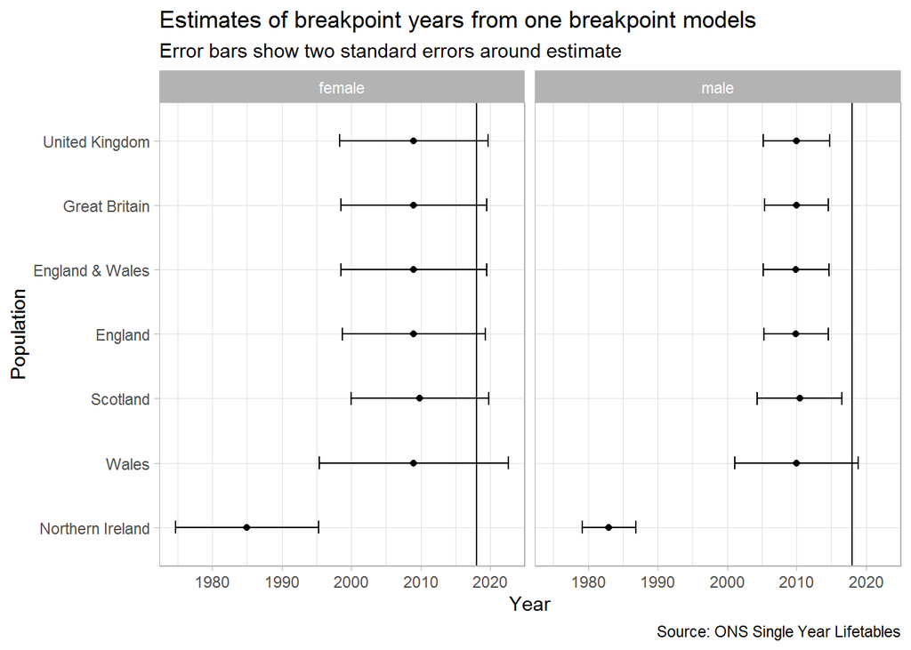

```r
datablocks %>%
  ungroup() %>%
  mutate(
    segmod_1brk  = segmods_1brk
  ) %>%
  mutate(
    brk_year = map_dbl(segmod_1brk, ~summary(.x)$psi[2]),
    brk_se   = map_dbl(segmod_1brk, ~summary(.x)$psi[3])
  ) %>%
  select(population, sex, brk_year, brk_se) %>%
  mutate(
    brk_lwr = brk_year - 2 * brk_se,
    brk_upr = brk_year + 2 * brk_se
  ) %>%
  mutate(
    population = fct_relevel(population, rev(c("United Kingdom", "Great Britain", "England & Wales", "England", "Scotland", "Wales", "Northern Ireland")))
  ) %>%
  ggplot(aes(x = brk_year, y = population)) +
  geom_point() +
  geom_errorbarh(aes(xmin = brk_lwr, xmax=brk_upr), height = 0.2) +
  facet_wrap(~sex) +
  geom_vline(xintercept = 2018) +
  labs(
    x = "Year",
    y = "Population",
    title = "Estimates of breakpoint years from one breakpoint models",
    subtitle = "Error bars show two standard errors around estimate",
    caption = "Source: ONS Single Year Lifetables"

  ) +
  theme_light()
```

This shows a lot of consistency in estimates of when the breakdown occurred. With the exception of Northern Ireland, we can use 2010 afterwards as ‘post-slowdown’, and the years from 1980 onwards as ‘pre-slowdown’.

Let’s do the same for the five one breakpoint models using different seeds

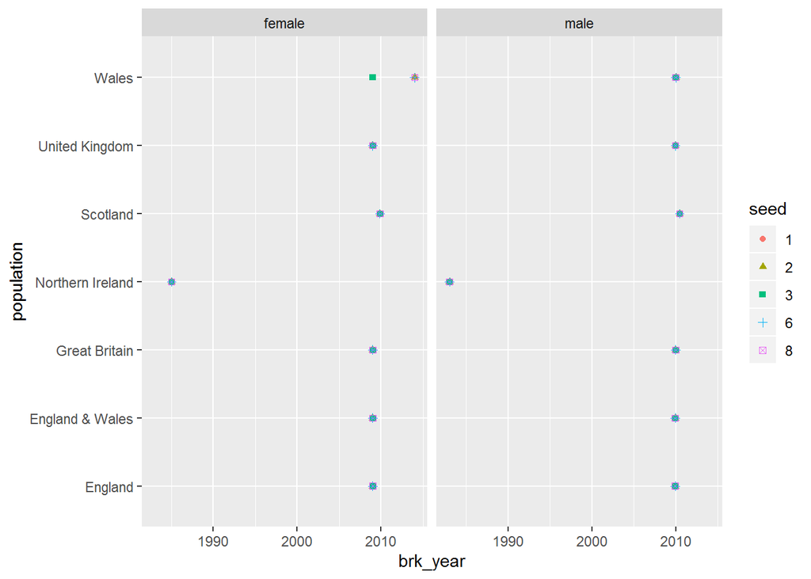

```r
datablocks %>%
  ungroup() %>%
  mutate(
    `1` = segmods1brk_seed01,
    `2` = segmods1brk_seed02,
    `3` = segmods1brk_seed03,
    `6` = segmods1brk_seed06,
    `8` = segmods1brk_seed08
  ) %>%
  select(population, sex, `1`:`8`) %>%
  gather(key = "seed", value = "model", `1`:`8`) %>%
  mutate(
    brk_year = map_dbl(model, ~summary(.x)$psi[2]),
    brk_sd   = map_dbl(model, ~summary(.x)$psi[3])
  ) %>%
  ggplot(aes(x = brk_year, y = population, group = seed, shape = seed, colour = seed)) +
  geom_point() +
  facet_wrap(~sex)
```

```r
# %>%
#   mutate(
#     brk_year = map_dbl(segmod_1brk, ~summary(.x)$psi[2]),
#     brk_se   = map_dbl(segmod_1brk, ~summary(.x)$psi[3])
#   ) %>%
#   select(population, sex, brk_year, brk_se) %>%
#   mutate(
#     brk_lwr = brk_year - 2 * brk_se,
#     brk_upr = brk_year + 2 * brk_se
#   ) %>%
#   mutate(
#     population = fct_relevel(population, rev(c("United Kingdom", "Great Britain", "England & Wales", "England", "Scotland", "Wales", "Northern Ireland")))
#   )
```

Break point years, where they can be calculated, are largely identical. They confirm 2010 as a reasonable breakpoint year except for Northern Ireland.

Now, let’s determine the average change (and SD) from 1980 to 2010

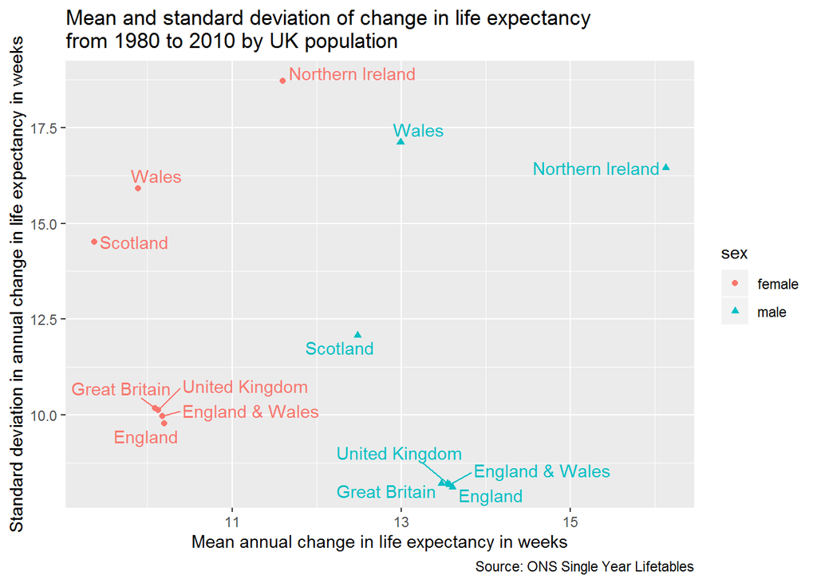

```r
dta_e0 %>%
  group_by(population, sex) %>%
  arrange(year) %>%
  mutate(ch_e0 = e0 - lag(e0)) %>%
  ungroup() %>%
  filter(!is.na(ch_e0)) %>%
  filter(year < 2010) %>%
  select(-e0) %>%
  group_by(population, sex) %>%
  arrange(year) %>%
  summarise(
    mean_ch = mean(ch_e0),
    sd_ch   = sd(ch_e0)
  ) %>%
  write_to_table(here("data", "mean_sd_ch_preslowdown_ons.csv")) %>%
  mutate(mean_ch = mean_ch * 52.25, sd_ch = sd_ch * 52.25) %>%
  ggplot(aes(x = mean_ch, y = sd_ch, shape = sex, colour = sex)) +
  geom_point() +
  geom_text_repel(aes(label = population, colour = sex), show.legend = FALSE) +
  labs(
    x = "Mean annual change in life expectancy in weeks",
    y = "Standard deviation in annual change in life expectancy in weeks",
    title = "Mean and standard deviation of change in life expectancy\nfrom 1980 to 2010 by UK population",
    caption = "Source: ONS Single Year Lifetables"
  ) +


ggsave(here("figures", "mean_sd_preslowdown_improvement_ons.png"), height = 20, width = 20, units = "cm", dpi = 300)
```

For each of these populations, we can estimate the relative likelihood of observing the observed life expectancies from 2011 onwards under the assumption that each population’s fundamentals of life expectancy improvement had not changed after 2010. This assumption is questionable for Northern Ireland because of its changepoint in the mid 1980s, but will be applied to this population too for consistency with the other populations.

```r
bf_uk_nations <-
  dta_e0 %>%
    group_by(population, sex) %>%
    arrange(year) %>%
    mutate(ch_e0 = e0 - lag(e0)) %>%
    ungroup() %>%
    filter(!is.na(ch_e0)) %>%
    select(-e0) %>%
    group_by(population, sex) %>%
    arrange(year) %>%
    nest() %>%
    crossing(after_end = 2011:2018) %>%
    mutate(
      bayes_df = map2(
        after_end, data, ~calc_bayes_factors(after_period = c(2011, .x), before_period = c(1981, 2010), outcome_var = ch_e0, dta = .y)
      )
    ) %>%
    select(population, sex, after_end, bayes_df) %>%
    unnest(cols = c(bayes_df)) %>%
    mutate(
      period = paste0("2011-", str_sub(after_end, 3,4))
    )

bf_uk_nations
```

| population | sex | after_end | perc | mu | ll | bayes_factor | period |
| --- | --- | --- | --- | --- | --- | --- | --- |
| England | female | 2011 | 1.00 | 0.192666667 | 0.77133255 | 1.0000000 | 2011-11 |
| England | female | 2011 | 0.99 | 0.190740000 | 0.77132087 | 0.9999883 | 2011-11 |
| England | female | 2011 | 0.98 | 0.188813333 | 0.77130907 | 0.9999765 | 2011-11 |
| England | female | 2011 | 0.97 | 0.186886667 | 0.77129714 | 0.9999646 | 2011-11 |
| England | female | 2011 | 0.96 | 0.184960000 | 0.77128509 | 0.9999525 | 2011-11 |
| England | female | 2011 | 0.95 | 0.183033333 | 0.77127290 | 0.9999404 | 2011-11 |
| England | female | 2011 | 0.94 | 0.181106667 | 0.77126060 | 0.9999280 | 2011-11 |
| England | female | 2011 | 0.93 | 0.179180000 | 0.77124816 | 0.9999156 | 2011-11 |
| England | female | 2011 | 0.92 | 0.177253333 | 0.77123560 | 0.9999031 | 2011-11 |
| England | female | 2011 | 0.91 | 0.175326667 | 0.77122292 | 0.9998904 | 2011-11 |

[output cut: 9990 more lines]

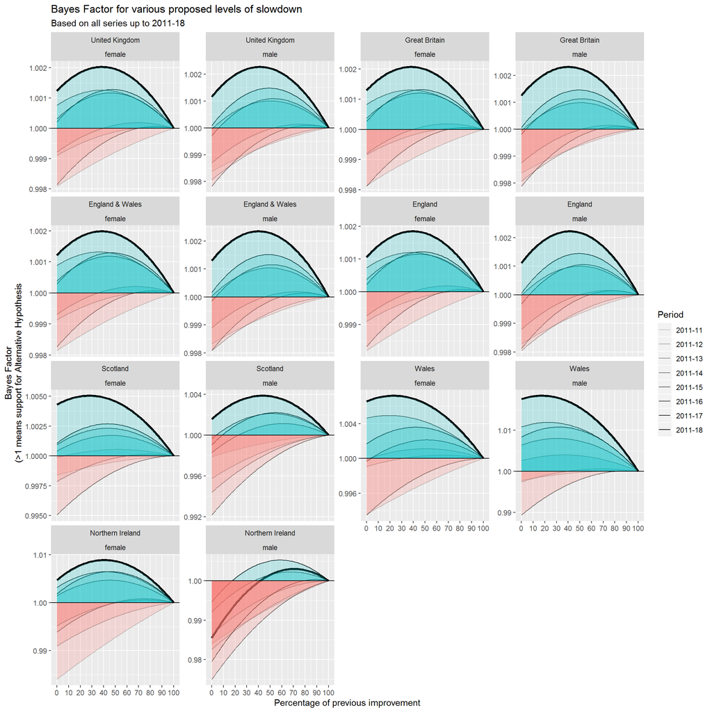

```r
bf_uk_nations %>%
  mutate(perc = 100 * perc) %>%
  mutate(
    population = fct_relevel(population, c("United Kingdom", "Great Britain", "England & Wales", "England", "Scotland", "Wales", "Northern Ireland"))
  ) %>%
  ggplot(aes(x = perc, y = bayes_factor, alpha = period)) +
  geom_line() +
  geom_line(aes(x = perc, y = bayes_factor), size = 1.4,
              data = bf_uk_nations %>%
                filter(period == "2011-18") %>%
                mutate(perc = 100 * perc) %>%
                mutate(
    population = fct_relevel(population, c("United Kingdom", "Great Britain", "England & Wales", "England", "Scotland", "Wales", "Northern Ireland"))
  ) %>%
                mutate(is_pos = bayes_factor > 1),
              inherit.aes = FALSE
            ) +
  facet_wrap(population ~ sex, scales = "free_y") +
  geom_ribbon(aes(
      ymin = ifelse(is_pos, 1, bayes_factor),
      ymax = ifelse(is_pos, bayes_factor, 1),
      x = perc, group = paste0(is_pos, period),
      fill = is_pos
    ),
              data = bf_uk_nations %>%
                mutate(perc = 100 * perc) %>%
                  mutate(
              population = fct_relevel(population, c("United Kingdom", "Great Britain", "England & Wales", "England", "Scotland", "Wales", "Northern Ireland"))
            ) %>%
                mutate(is_pos = bayes_factor > 1),
              inherit.aes = FALSE, alpha = 0.2) +
  # scale_y_continuous(limits = c(0.999, 1.008),
  #                    breaks = seq(0.999, 1.0080, by = 0.001)
  #
  #                      ) +
  scale_alpha_discrete("Period", range = c(0.2, 1), breaks = c("2011-11", "2011-12", "2011-13", "2011-14", "2011-15", "2011-16", "2011-17", "2011-18")) +
  geom_hline(yintercept = 1) +
  labs(
    x = "Percentage of previous improvement",
    y = "Bayes Factor\n(>1 means support for Alternative Hypothesis",
    title = "Bayes Factor for various proposed levels of slowdown",
    subtitle = "Based on all series up to 2011-18"
  ) +
  guides(fill = FALSE) +
  scale_x_continuous(breaks = seq(0, 100, by = 10))
```

For all populations except males in Northern Ireland, the addition of the 2018 single year life expectancy data led to sizeable increases in the empirical support for the belief that there has been a slowdown in life expectancy after 2010; this is seen by noting how much higher the bold line, which incorporates the 2018 data, is than the fainter lines representing cumulative data based on shorter series of observations. For most of these populations, the peak of the bold line is to the left of peaks based on earlier series, meaning not only did the 2018 observations increase the strength of evidence supporting belief in a slowdown in life expectancy improvements, but also suggested more severe magnitudes of slowdown than the series excluding this most recent observation had indicated. For the UK as a whole, the addition of the life expectancy data for 2018 suggested an overall slowdown of around 60% was most likely, compared with a most likely magnitude of slowdown of around 50% based on data up to 2017. For each of these populations, what does the Bayes Factor maximise at?

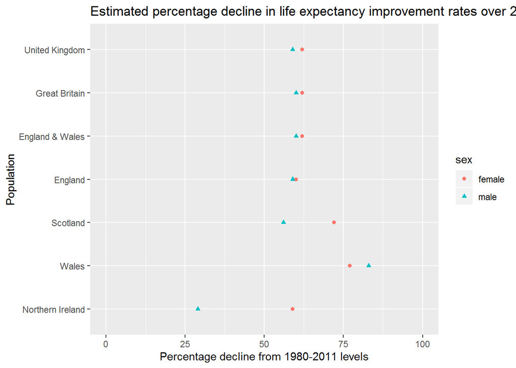

```r
bf_uk_nations %>%
   filter(period == "2011-18") %>%
   mutate(perc = 100 * perc) %>%
   mutate(
    population = factor(population, levels = rev(c("United Kingdom", "Great Britain", "England & Wales", "England", "Scotland", "Wales", "Northern Ireland")))
  ) %>%
  group_by(sex, population) %>%
  filter(bayes_factor == max(bayes_factor)) %>%
  ungroup() %>%
  ggplot(aes(y = population, x = 100 - perc, shape = sex, colour = sex)) +
  geom_point() +
  labs(
    x = "Percentage decline from 1980-2011 levels",
    y = "Population",
    title = "Estimated percentage decline in life expectancy improvement rates over 2011-2018 compared with 1981-2010"
  ) +
  lims(x = c(0, 100))
```

And as a table

```r
bf_uk_nations %>%
   filter(period == "2011-18") %>%
   mutate(perc = 100 * perc) %>%
   mutate(
    population = factor(population, levels = rev(c("United Kingdom", "Great Britain", "England & Wales", "England", "Scotland", "Wales", "Northern Ireland")))
  ) %>%
  group_by(sex, population) %>%
  filter(bayes_factor == max(bayes_factor)) %>%
  ungroup() %>%
  select(population, sex, perc, bayes_factor) %>%
  mutate(perc = 100 - perc)
```

| population | sex | perc | bayes_factor |
| --- | --- | --- | --- |
| England | female | 60 | 1.001844 |
| England | male | 59 | 1.002219 |
| England & Wales | female | 62 | 1.001988 |
| England & Wales | male | 60 | 1.002346 |
| Great Britain | female | 62 | 1.002063 |
| Great Britain | male | 60 | 1.002316 |
| Northern Ireland | female | 59 | 1.008875 |
| Northern Ireland | male | 29 | 1.003023 |
| Scotland | female | 72 | 1.005048 |
| Scotland | male | 56 | 1.003858 |

[output cut: 4 more lines]

In the UK as a whole, it is most likely that life expectancy improvement rates have slowed down by 62% for females, and 59% for males. This is made up of a 60% (females) and 59% (males) slowdown in England, a 72% (females) and 56% (males) slowdown in Scotland, a 59% (females) and 29% (males) slowdown in Northern Ireland, and an estimated 77% (females) and 83% (males) slowdown in Wales. With the exception of males in Northern Ireland, rates of slowdown are therefore similar across UK nations, and generally slightly more severe for females than males.

Some important points:

- This approach means that the process of updating beliefs about the extent and evidence for a slowdown in life expectancy gains can be made formally rather than informally.
- The Bayes Factor schedules can be recalculated whenever a new data release becomes available. This means that updated schedules can be produced within minutes of the release of official statistics. The commitment to do this each each new release, and to publish updated estimates of support for slowdown, should be made before such data are released.
- The tendency within UK populations has been for the rate of slowdown to be increasing over time, rather than to shift suddenly from one rate to another. If this continues then the proposed slowdown percentage that maximises the bayes factor will continue to shift further to the left with additional years’ data, and could be maximised at a negative value (i.e. declining life expectancy rather than slowing improvement) if this tendency continues.